# MeLi - Challenge

### Julio, 2021

## Índice

- 1. Contexto y objetivo
- 1. Marco Teórico
- 1. Entendimiento y preparación de datos
- 1. Análisis exploratorio
- 1. Entrenamiento y evaluación del modelo
- 1. Conclusiones

## Contexto y objetivo

Los pagos realizados a través de Mercadopago han crecido exponencialmente mes a mes los últimos años, al punto tal de que hoy en día el volumen de transacciones realizadas por fuera del marketplace superan a las realizadas internamente. Parte de este crecimiento está en la prevención de fraude en los distintos productos de MercadoPago.. Esto es vital para garantizar una excelente experiencia para los usuarios y reducir las pérdidas económicas por fraudes.

El fraude en plataformas de pagos, es una problemática mundial que representa pérdidas económicas a gran escala. MercadoPago, por su dimensión y presencia regional, es blanco de este tipo de ataques diariamente. Construir modelos de machine learning para prevención de fraude robustos y escalables que analicen todo el flujo de pagos es indispensable para la seguridad de nuestros usuarios.

**Objetivo**: Construir una solución basada en Machine Learning para predecir si una transacción es fraudulenta o no.

## Marco Teórico

Para dar respuesta a lo anterior se construyen varios modelos de clasificación para cada país en la muestra de datos. Lo anterior debido a que se observa que el comportamiento transaccional entre países es muy diferente, por lo cual es complejo construir un solo modelo que logre capturar todo.

### Modelos usados

- Clustering: K-Means.
- Reducción de la dimensionalidad: T-SNE.
- Clasificación: Regresión Logística, KNN, Random Forest, y XGBoost.

Si bien se usó clustering con el fin de entender la estructura de los datos teniendo en cuenta las relaciones entre todas las variables. Los resultados no fueron satisfactorios, debido a que se encontraron los grupos óptimos pero la mayoría de observaciones quedaban en un clúster con muchas observaciones.

```python
import warnings
import numpy as np
import pandas as pd
import seaborn as sns
from collections import Counter
from sklearn import set_config
import matplotlib.pyplot as plt
from xgboost import XGBClassifier
from sklearn.manifold import TSNE
from sklearn.pipeline import Pipeline
from sklearn.impute import KNNImputer
from sklearn.preprocessing import RobustScaler
from sklearn.neighbors import KNeighborsClassifier
from sklearn.linear_model import LogisticRegression
from sklearn.ensemble import RandomForestClassifier
from utilities.evaluation import ClassificationEvaluator
from sklearn.model_selection import RepeatedStratifiedKFold, GridSearchCV
from utilities.data_wrangling import cross_validation_result, export_data
from utilities.modeling import cross_validation, create_preprocess_pipeline, save_model, variance_inflation
from utilities.plotting import bar_plot, box_plot, heat_map, plot_feature_importance, distribution_plot
from utilities.utils import beta_interpretation, split_train_test_data, calculate_shap_values, characterization_data

from IPython.display import display

set_config(display='diagram')
pd.set_option("max_columns", 50)
pd.set_option("float_format", "{:.2f}".format)

warnings.filterwarnings(action="ignore")
```

## Entendimiento y preparación de datos

En total son 16.880 observaciones y 21 variables. La mayoría de variables se cargan como variables numéricas, por tanto, se supone que las variables vienen así desde la fuente y no se les ha hecho un tratamiento de codificación o algo por el estilo. Tres variables no se cargan bien, dado que se cargan como tipo *object* cuando en realidad son numéricas, específicamente, Q, R y Monto por lo que se corrige esto después de la carga del archivo.

```python
data = pd.read_csv("data/MercadoLibre Inc. Data Scientist Hiring Test - Fraud Dataset  - Data (2) (2).csv",
                   decimal=".")

print(f"Total observaciones: {data.shape[0]}, Total variables: {data.shape[1]} \n")
data.head(n=2)
```

```
Total observaciones: 16880, Total variables: 21
```

|  | A | B | C | D | E | F | G | H | I | J | K | L | M | N | O | P | Q | R | S | Monto | Fraude |
| --- | --- | --- | --- | --- | --- | --- | --- | --- | --- | --- | --- | --- | --- | --- | --- | --- | --- | --- | --- | --- | --- |
| 0 | 0 | 10 | 50257.00 | 0 | 0 | 0.00 | 0.00 | 0 | 0 | UY | 0.80 | 0 | 3 | 1 | 0 | 5 | 0.00 | 0.00 | 7.25 | 37.51 | 1 |
| 1 | 0 | 10 | 29014.00 | 0 | 0 | 0.00 | 0.00 | 0 | 0 | UY | NaN | 0 | 1 | 1 | 0 | 3 | 0.00 | 0.00 | 11.66 | 8.18 | 1 |

Todo lo demás parece haber cargado correctamente. Para avanzar un poco más rápido con la clase *ProfileReport* del módulo Pandas Profiling se genera un archivo **output.html** donde se ve un análisis exploratorio sencillo.

```python
data.info()
```

```
<class 'pandas.core.frame.DataFrame'>
RangeIndex: 16880 entries, 0 to 16879
Data columns (total 21 columns):
 #   Column  Non-Null Count  Dtype
---  ------  --------------  -----
 0   A       16880 non-null  int64
 1   B       16880 non-null  int64
 2   C       13683 non-null  float64
 3   D       16880 non-null  int64
 4   E       16880 non-null  int64
 5   F       16880 non-null  float64
 6   G       16880 non-null  float64
 7   H       16880 non-null  int64
 8   I       16880 non-null  int64
 9   J       16880 non-null  object
 10  K       4016 non-null   float64
 11  L       16880 non-null  int64
 12  M       16880 non-null  int64
 13  N       16880 non-null  int64
 14  O       16880 non-null  int64
 15  P       16880 non-null  int64
 16  Q       16880 non-null  object
 17  R       16880 non-null  object
 18  S       16880 non-null  float64
 19  Monto   16880 non-null  object
 20  Fraude  16880 non-null  int64
dtypes: float64(5), int64(12), object(4)
memory usage: 2.7+ MB
```

```python
for col in ["Q", "R", "Monto"]:
    data[col] = data[col].str.replace(",", "").apply(lambda x: float(x))
```

Algunos resultados interesantes que se pueden observar desde el reporte, es que la mayoría de variables tienen un sesgo positivo, por lo que claramente hay presencia de datos atípicos.

Por otro lado, hay dos variables que tienen datos missing, por un lado la variable K que tiene al rededor de un 76.2% de missing. Así las cosas, se decide eliminar esta variable dado que no se recomienda imputar una cantidad tan alta porque seguramente le cambiaremos la distribución a los datos.

A continuación, vemos en una tabla el porcentaje de datos missing por columnas.

```python
is_missing = data.isna()

pd.DataFrame.from_dict({"quant_missing": is_missing.sum(),
                        "perc_missing": is_missing.mean() * 100})
```

|  | quant_missing | perc_missing |
| --- | --- | --- |
| A | 0 | 0.00 |
| B | 0 | 0.00 |
| C | 3197 | 18.94 |
| D | 0 | 0.00 |
| E | 0 | 0.00 |
| F | 0 | 0.00 |
| G | 0 | 0.00 |
| H | 0 | 0.00 |
| I | 0 | 0.00 |
| J | 0 | 0.00 |
| K | 12864 | 76.21 |
| L | 0 | 0.00 |
| M | 0 | 0.00 |
| N | 0 | 0.00 |
| O | 0 | 0.00 |
| P | 0 | 0.00 |
| Q | 0 | 0.00 |
| R | 0 | 0.00 |
| S | 0 | 0.00 |
| Monto | 0 | 0.00 |
| Fraude | 0 | 0.00 |

Como se menciona, se elimina la variable K. La variable C también tiene una cantidad alta de datos missing, sin embargo, por lo general se recomienda que se puede imputar hasta un 20% aproximadamente, pero teniendo en cuenta que la distribución de los datos no cambie después de haber imputado

```python
data = data.drop(labels=["K"], axis="columns")
```

Del reporte también observamos que las variables B y S tienen un valor mínimo de -1. Se supone que este valor se coloca así cuando falta información para una de estas variables, además se calcula el porcentaje de datos que se perderían al eliminarse del set de datos.

A continuación, vemos una tabla con el porcentaje de datos -1 que tiene cada columna.

```python
is_negative = data == -1

pd.DataFrame(data={"quant_negative": is_negative.sum(),
                   "perc_negative": is_negative.mean() * 100})
```

|  | quant_negative | perc_negative |
| --- | --- | --- |
| A | 0 | 0.00 |
| B | 125 | 0.74 |
| C | 0 | 0.00 |
| D | 0 | 0.00 |
| E | 0 | 0.00 |
| F | 0 | 0.00 |
| G | 0 | 0.00 |
| H | 0 | 0.00 |
| I | 0 | 0.00 |
| J | 0 | 0.00 |
| L | 0 | 0.00 |
| M | 0 | 0.00 |
| N | 0 | 0.00 |
| O | 0 | 0.00 |
| P | 0 | 0.00 |
| Q | 0 | 0.00 |
| R | 0 | 0.00 |
| S | 136 | 0.81 |
| Monto | 0 | 0.00 |
| Fraude | 0 | 0.00 |

Hay muy pocas observaciones que tienen este comportamiento, por lo que se decide eliminar, dado que no se perderá mucha información.

```python
idx = data[(data["B"] == -1) | (data["S"] == -1)].index.tolist()

data = data.drop(index=idx, axis="index")
print(f"Se han eliminado {len(idx)} observaciones.")
```

```
Se han eliminado 256 observaciones.
```

Por otro lado, la variable J que supongo que es el país donde se hizo la transacción, tiene unas categorías poco representadas.

A continuación se cogen esas observaciones que representan apenas el 1% de la información total.

```python
aux = data["J"].value_counts(normalize=True).sort_values(ascending=True)
flag = aux.cumsum() * 100 < 1.0

data[data["J"].isin(aux.index[flag].tolist())]
```

|  | A | B | C | D | E | F | G | H | I | J | L | M | N | O | P | Q | R | S | Monto | Fraude |
| --- | --- | --- | --- | --- | --- | --- | --- | --- | --- | --- | --- | --- | --- | --- | --- | --- | --- | --- | --- | --- |
| 10136 | 0 | 1 | 363365.00 | 0 | 0 | 0.00 | 0.00 | 0 | 0 | CA | 2 | 2 | 2 | 0 | 2 | 0.00 | 0.00 | 2.11 | 12.18 | 0 |
| 10169 | 0 | 4 | 561.00 | 0 | 0 | 0.00 | 0.00 | 0 | 0 | GB | 1 | 1 | 1 | 0 | 1 | 0.00 | 0.00 | 21.28 | 15.91 | 0 |
| 10217 | 0 | 17 | NaN | 0 | 0 | 0.00 | 0.00 | 0 | 0 | CA | 1 | 1 | 1 | 0 | 2 | 0.00 | 0.00 | 22.21 | 32.40 | 0 |
| 10270 | 0 | 1 | 2402.00 | 0 | 0 | 0.00 | 0.00 | 0 | 0 | UA | 1 | 1 | 1 | 0 | 1 | 0.00 | 0.00 | 4.20 | 79.53 | 0 |
| 10284 | 0 | 7 | 93467.00 | 0 | 0 | 0.00 | 0.00 | 0 | 0 | CA | 1 | 1 | 1 | 0 | 1 | 0.00 | 0.00 | 19.94 | 27.90 | 0 |
| 10402 | 0 | 1 | 3276.00 | 2 | 4 | 0.02 | 0.00 | 0 | 0 | CL | 1 | 1 | 1 | 0 | 1 | 0.00 | 0.00 | 1.09 | 62.19 | 0 |
| 10478 | 0 | 1 | 16409.00 | 0 | 1 | 1.00 | 0.00 | 0 | 0 | CO | 1 | 1 | 1 | 0 | 1 | 0.00 | 0.00 | 0.19 | 10.37 | 0 |
| 10541 | 0 | 3 | 1241.00 | 0 | 0 | 0.00 | 0.00 | 0 | 0 | CA | 0 | 1 | 1 | 0 | 1 | 0.00 | 0.00 | 55.91 | 90.97 | 0 |
| 10570 | 0 | 2 | 17082.00 | 0 | 0 | 0.00 | 0.00 | 0 | 0 | CA | 0 | 3 | 1 | 0 | 2 | 0.00 | 0.00 | 6.92 | 318.92 | 0 |
| 10605 | 0 | 1 | 787.00 | 0 | 0 | 0.00 | 0.00 | 0 | 0 | IT | 1 | 1 | 1 | 0 | 1 | 0.00 | 0.00 | 0.45 | 93.10 | 0 |
| 10770 | 0 | 1 | 55.00 | 0 | 0 | 0.00 | 0.00 | 0 | 0 | GT | 1 | 1 | 1 | 0 | 1 | 0.00 | 0.00 | 4.33 | 545.97 | 0 |
| 10793 | 0 | 2 | 5490.00 | 0 | 0 | 0.00 | 0.00 | 0 | 0 | PT | 1 | 2 | 2 | 0 | 1 | 20.07 | 0.00 | 2.34 | 20.16 | 0 |
| 10824 | 0 | 1 | 9379.00 | 0 | 0 | 0.00 | 0.00 | 0 | 0 | CH | 1 | 1 | 1 | 0 | 1 | 0.00 | 0.00 | 2.92 | 10.59 | 0 |
| 10886 | 0 | 1 | 6053.00 | 0 | 0 | 0.00 | 0.00 | 0 | 0 | GB | 1 | 1 | 1 | 0 | 2 | 0.00 | 0.00 | 31.73 | 20.32 | 0 |
| 10998 | 0 | 1 | 21368.00 | 0 | 0 | 0.00 | 0.00 | 0 | 0 | TR | 1 | 1 | 1 | 0 | 1 | 0.00 | 0.00 | 1.08 | 15.29 | 0 |
| 11059 | 0 | 2 | 2195.00 | 0 | 0 | 0.00 | 0.00 | 0 | 0 | FR | 1 | 1 | 1 | 0 | 1 | 0.00 | 0.00 | 10.72 | 55.66 | 0 |
| 11075 | 0 | 13 | 0.00 | 0 | 0 | 0.00 | 0.00 | 0 | 0 | CA | 0 | 2 | 1 | 0 | 1 | 0.00 | 0.00 | 44.78 | 29.78 | 0 |
| 11233 | 0 | 1 | 8329.00 | 0 | 0 | 0.00 | 0.00 | 0 | 0 | CA | 1 | 1 | 1 | 0 | 1 | 0.00 | 0.00 | 24.46 | 13.48 | 0 |
| 11280 | 0 | 2 | 2578.00 | 0 | 0 | 0.00 | 0.00 | 0 | 0 | KR | 2 | 2 | 2 | 0 | 2 | 0.00 | 0.00 | 2.07 | 14.19 | 0 |
| 11291 | 0 | 1 | 556545.00 | 1 | 0 | 0.00 | 0.01 | 0 | 0 | GB | 1 | 2 | 2 | 0 | 1 | 0.00 | 0.00 | 5.22 | 34.44 | 0 |
| 11302 | 0 | 1 | 29749.00 | 2 | 0 | 0.00 | 0.01 | 0 | 0 | GB | 1 | 2 | 2 | 0 | 1 | 34.44 | 0.00 | 7.00 | 9.50 | 0 |
| 11303 | 0 | 1 | 7642.00 | 0 | 0 | 0.00 | 0.00 | 0 | 0 | AU | 1 | 1 | 1 | 0 | 1 | 0.00 | 0.00 | 0.74 | 28.65 | 0 |
| 11308 | 0 | 1 | 556617.00 | 2 | 0 | 0.00 | 0.01 | 0 | 0 | GB | 1 | 2 | 2 | 0 | 1 | 34.44 | 0.00 | 6.53 | 14.59 | 0 |
| 11348 | 0 | 1 | 15090.00 | 0 | 0 | 0.00 | 0.00 | 0 | 0 | GB | 1 | 1 | 1 | 0 | 2 | 0.00 | 0.00 | 5.51 | 14.27 | 0 |
| 11564 | 0 | 1 | 74470.00 | 0 | 0 | 0.00 | 0.00 | 0 | 0 | GB | 1 | 1 | 1 | 0 | 1 | 29.59 | 0.00 | 3.11 | 29.59 | 0 |
| 11724 | 0 | 3 | 8344.00 | 0 | 0 | 0.00 | 0.00 | 0 | 0 | FR | 0 | 1 | 1 | 0 | 2 | 0.00 | 0.00 | 8.82 | 10.56 | 0 |
| 11830 | 0 | 3 | 3571.00 | 0 | 0 | 0.00 | 0.00 | 0 | 0 | GT | 1 | 1 | 1 | 0 | 1 | 0.00 | 0.00 | 2.45 | 91.09 | 0 |
| 11855 | 0 | 1 | 258.00 | 0 | 0 | 0.00 | 0.00 | 0 | 0 | CA | 0 | 1 | 1 | 0 | 2 | 0.00 | 0.00 | 17.36 | 34.62 | 0 |
| 11922 | 0 | 1 | 835.00 | 0 | 0 | 0.00 | 0.00 | 0 | 0 | CA | 1 | 1 | 1 | 0 | 1 | 0.00 | 0.00 | 7.41 | 38.30 | 0 |
| 11934 | 0 | 3 | 7111.00 | 0 | 0 | 0.00 | 0.00 | 0 | 0 | CA | 1 | 1 | 1 | 0 | 1 | 0.00 | 0.00 | 18.96 | 15.98 | 0 |
| 12201 | 0 | 9 | NaN | 0 | 0 | 0.00 | 0.00 | 0 | 0 | CA | 0 | 1 | 1 | 0 | 1 | 0.00 | 0.00 | 34.61 | 36.65 | 0 |
| 12390 | 0 | 1 | 21191.00 | 3 | 0 | 0.00 | 0.00 | 0 | 0 | GB | 2 | 3 | 3 | 0 | 2 | 58.53 | 0.00 | 2.43 | 37.18 | 0 |
| 12410 | 0 | 2 | 53.00 | 0 | 0 | 0.00 | 0.00 | 0 | 0 | CA | 1 | 1 | 1 | 0 | 1 | 0.00 | 0.00 | 24.38 | 335.59 | 0 |

Vemos que estos 13 países por un lado están poco representados (Juntos conforman apenas el 1% de los datos). Adicional podemos ver países donde solo hay una observación, por lo que un algoritmo no podrá aprender para generalizar, además que este 1% todos tienen la etiqueta en que no se cometió Fraude por lo que se eliminarán estas observaciones y no se creará otra categoría con estos países.

A continuación se muestra la cantidad de transacciones fraudulentas y no fraudulentas para cada país, para visualizar lo antes mencionado.

```python
pd.crosstab(index=data["J"], columns=data["Fraude"]).style.background_gradient()
```

| Fraude J | 0 | 1 |
| --- | --- | --- |
| AR | 6602 | 2577 |
| AU | 1 | 0 |
| BR | 3287 | 1087 |
| CA | 12 | 0 |
| CH | 1 | 0 |
| CL | 1 | 0 |
| CO | 1 | 0 |
| ES | 19 | 291 |
| FR | 2 | 0 |
| GB | 8 | 0 |
| GT | 2 | 0 |
| IT | 1 | 0 |
| KR | 1 | 0 |
| MX | 2135 | 215 |
| PT | 1 | 0 |
| TR | 1 | 0 |
| UA | 1 | 0 |
| US | 34 | 170 |
| UY | 0 | 174 |

Otro comportamiento similar lo vemos con *UY* dado que está poco representado y todas sus observaciones son fraudes, por lo cual un modelo no aprendería a discriminar entre transacciones fraudulentas o no fraudulentas para este país. Por tanto, se procede a eliminar las observaciones de *UY* y los otros trece países; además que entre todas no representan ni el 2% del total de observaciones, por lo cual no se pierde mucha información.

```python
idx = data[data["J"].isin(aux.index[flag].tolist() + ["UY"])].index.tolist()

data = data.drop(index=idx, axis="index")
print(f"Se han eliminado {len(idx)} observaciones.")
```

```
Se han eliminado 207 observaciones.
```

## Análisis exploratorio

El análisis exploratorio es una parte muy importante, debido a que profundizamos en el entendimiento de los datos y eso nos ayuda a tomar deciiones más informadas para construir los modelos. Este análisis exploratorio se parte en varias etapas:

- Análisis univariado.
  - Variables categóricas.
  - Variables numéricas.
- Análisis bivariado, para ver la relación o asociación que hay entre las variables independientes y la variable dependiente.
- Análisis multivariado.
  - Reducción de la dimensionalidad usando T-SNE.

### Análisis univariado

Primero vamos a ver como se distribuyen los países con los que nos quedamos para la construcción del modelo.

#### Variables categóricas

```python
numerical_features = [col for col in data.select_dtypes(include="number").columns if col != "Fraude"]

categorical_features = data.select_dtypes(exclude="number").columns.tolist()
```

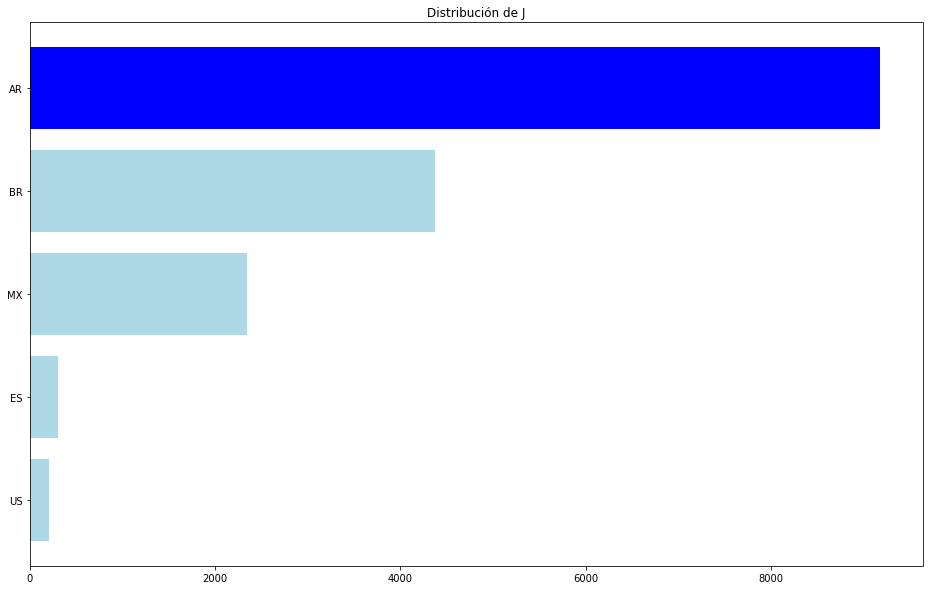

```python
bar_plot(dataframe=data, column="J")
```

AR es el país con más observaciones, y los países menos representados son ES, US. Ahora procedemos a ver como se distribuyen las variables numéricas, si bien, el reporte ya nos mostró un poco de esto, pero vamos a mirar como se distribuye cada variable por país.

#### Variables numéricas

```
Para la columna A:
```

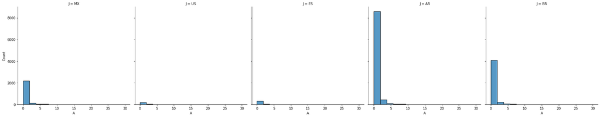

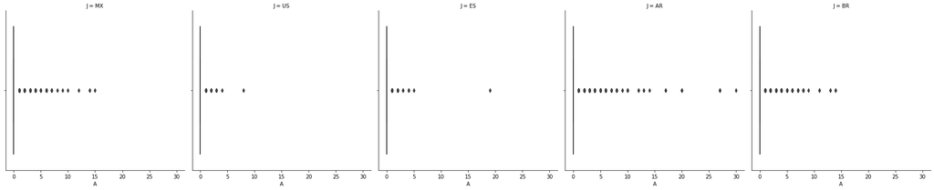

```
------------------------------------------

Para la columna B:
```

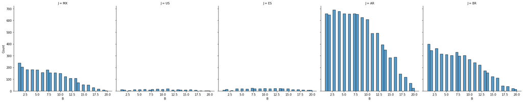

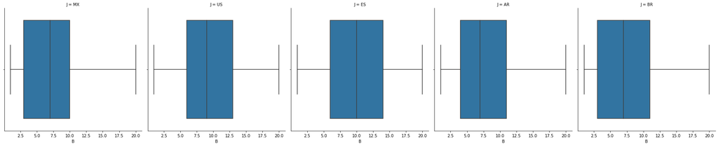

```
------------------------------------------

Para la columna C:
```

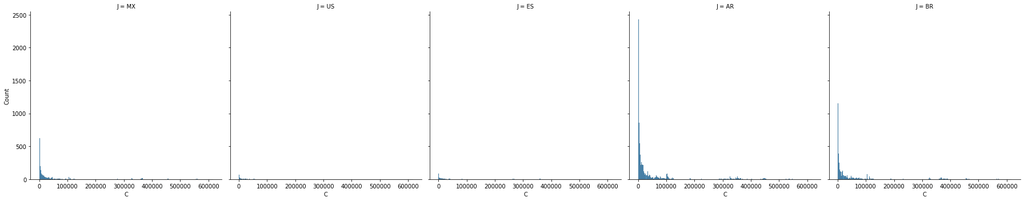

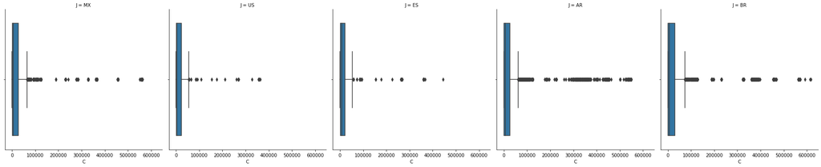

```
------------------------------------------

Para la columna D:
```

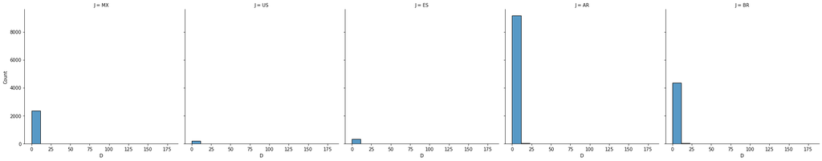

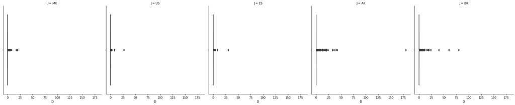

```
------------------------------------------

Para la columna E:
```

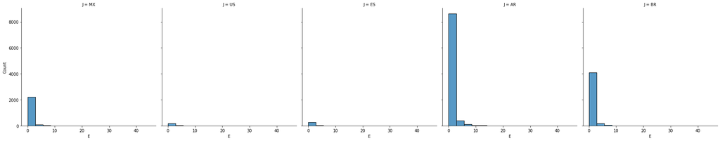

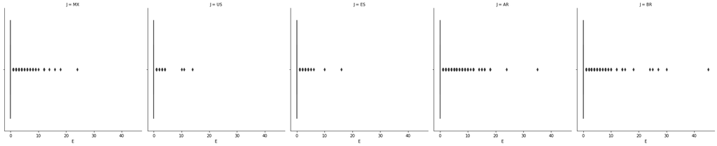

```
------------------------------------------

Para la columna F:
```

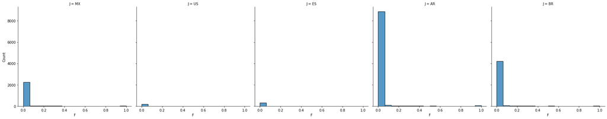

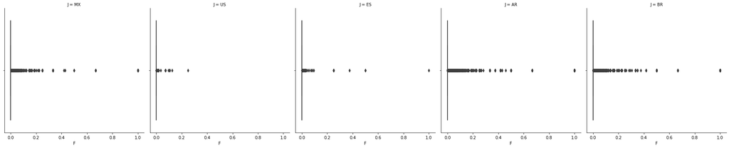

```
------------------------------------------

Para la columna G:
```

[24 more figures not shown]

```python
for col in numerical_features:
    print(f"Para la columna {col}:")
    distribution_plot(dataframe=data, column=col, col="J")
    plt.show()
    box_plot(dataframe=data, column=col, col="J")
    plt.show()
    print("------------------------------------------ \n")
```

Como habíamos visto desde el reporte, las variables presentan sesgos positivos y esto es un comportamiento general que se da para cada variable independientemente del país. Dado que hay presencia de datos atípicos, se procede a trabajar con ellos sin hacer ningún tratamiento como eliminarlos, o imputarlos.

### Análisis bivariado

Si bien el análisis univariado nos da cierta información, se queda corto para observar si hay relaciones entre las variables independientes y la variable dependiente. Dado que la variable objetivo es una variable categórica, y la mayoría de nuestras variables son numéricas podemos usar los diagramas de caja i bigotes para ver si hay diferencias entre la distribución del comportamiento fraudulento y no fraudulento en cada variable.

```
Para la variable A:
```

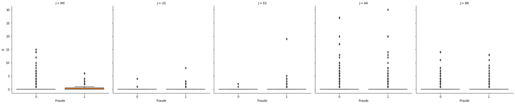

```
--------------------------------------------

Para la variable B:
```

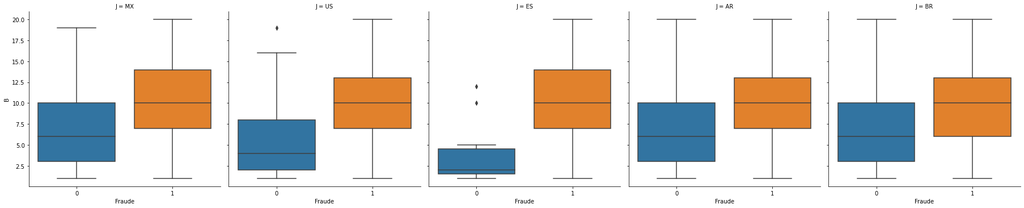

```
--------------------------------------------

Para la variable C:
```

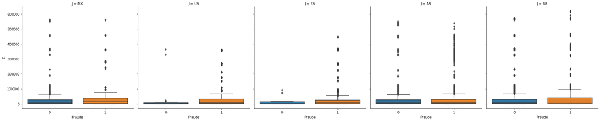

```
--------------------------------------------

Para la variable D:
```

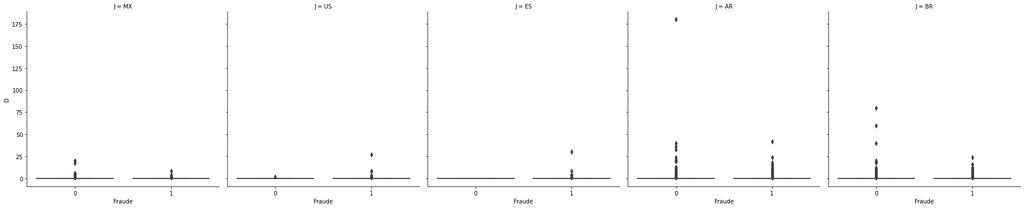

```
--------------------------------------------

Para la variable E:
```

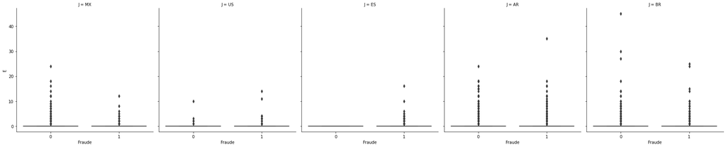

```
--------------------------------------------

Para la variable F:
```

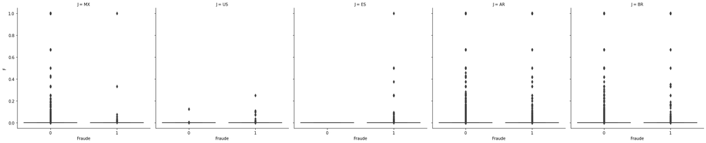

```
--------------------------------------------

Para la variable G:
```

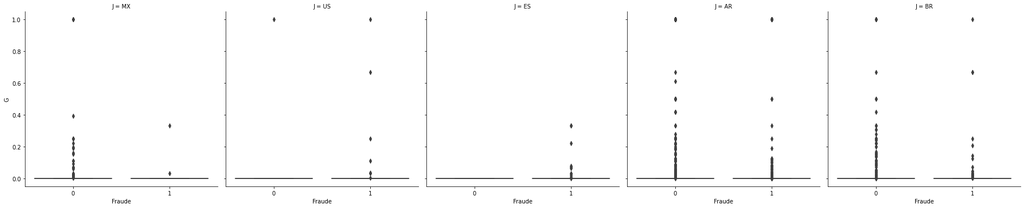

```
--------------------------------------------

Para la variable H:
```

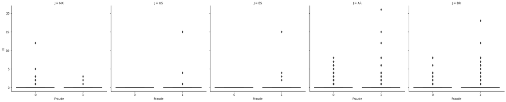

```
--------------------------------------------

Para la variable I:
```

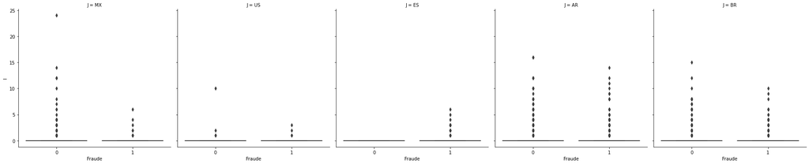

```
--------------------------------------------

Para la variable L:
```

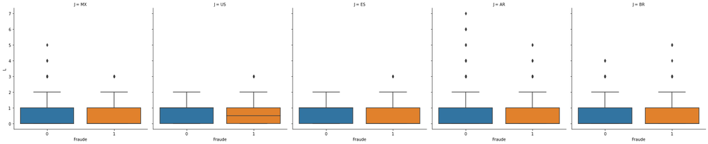

```
--------------------------------------------

Para la variable M:
```

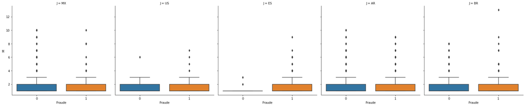

```
--------------------------------------------

Para la variable N:
```

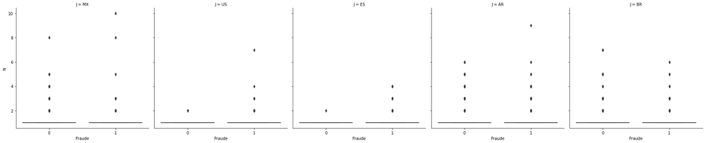

```
--------------------------------------------

Para la variable O:
```

[6 more figures not shown]

```python
for col in numerical_features:
    print(f"Para la variable {col}:")
    box_plot(dataframe=data, column=col, label="Fraude", col="J")
    plt.show()
    print("-------------------------------------------- \n")
```

Por último, se hará un análisis multivariado donde la idea es ver la relación entre todas las variables. Dado que nuestros datos tienen datos missing, se procede a imputar la variable C por cada país, debido a que en cada país si bien la distribución de cada variable es muy similar puede tener diferencias sobretodo con respecto a US y ES. Así las cosas se imputa los datos usando un KNN con el número de vecinos por defecto que es igual a 5 para cada país.

```python
data_imputed = data.copy()

for country in data_imputed["J"].unique():
    data_imputed.loc[data_imputed["J"] == country,
             numerical_features] = KNNImputer().fit_transform(data_imputed[data_imputed["J"] == country][numerical_features])
```

El tratamiento de datos missing por lo general está condicionado por el tipo de mecanismo que lo genera, sin embargo, a veces es complejo saber con seguridad si el mecanismo es MCAR, MAR o MNAR algo que nos puede ayudar en la práctica es imputar los datos y verificar que la distribución de los datos no haya cambiado después de haber imputado, debido a que esto nos llevaría a posibles resultados sesgados.

A continuación vemos en la primera fila la distribución antes de imputar, y en la segunda fila la distribución después de imputar.

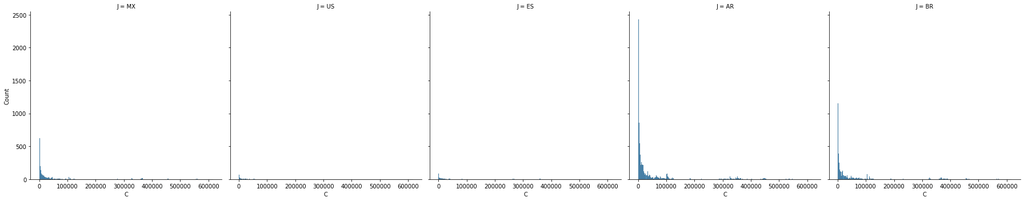

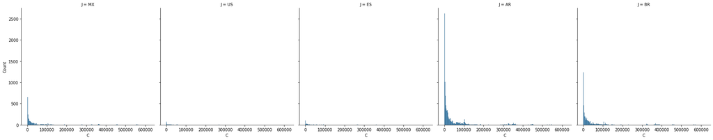

```python
distribution_plot(dataframe=data, column="C", col="J")
distribution_plot(dataframe=data_imputed, column="C", col="J")
```

### Análisis multivariado

Algo que nos interesa es mirar si las variables independientes están correlacionadas entre sí, con el fin de no tener información redundante.

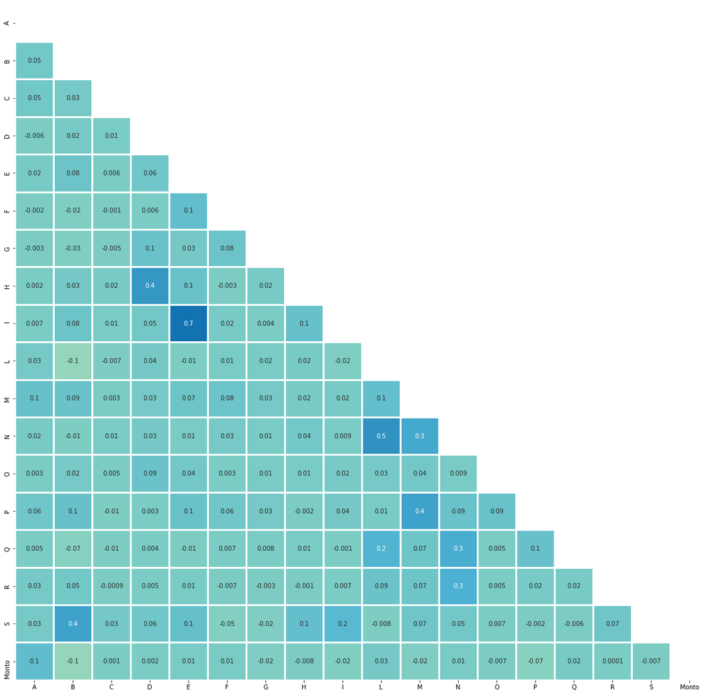

```python
correlation = data.drop(labels=["Fraude"], axis=1).corr()

mask = np.triu(correlation)

plt.figure(figsize=(20, 20))
heat_map(dataframe=correlation, vmin=-1, vmax=1, center=0, cmap="GnBu", cbar=False, mask=mask)
```

Podemos ver que hay una correlación alta entre la variable I y E, sin embargo, no e suna correlación tan alta como para pensar que puede existir multicolinealidad. Sin embargo, se procede a calcular el VIF para cada variable para verificar si hay problemas de multicolinealidad.

**Nota**: Se considera que existe multicolinealidad si el VIF > 5.

```python
data_vif = pd.get_dummies(data=data_imputed, columns=categorical_features)

variance_inflation(data_transformed=data_vif.drop(labels=["Fraude"], axis=1))
```

|  | feature | VIF |
| --- | --- | --- |
| 0 | A | 1.04 |
| 1 | B | 1.24 |
| 2 | C | 1.00 |
| 3 | D | 1.25 |
| 4 | E | 1.89 |
| 5 | F | 1.05 |
| 6 | G | 1.02 |
| 7 | H | 1.25 |
| 8 | I | 1.87 |
| 9 | L | 1.32 |
| 10 | M | 1.30 |
| 11 | N | 1.55 |
| 12 | O | 1.02 |
| 13 | P | 1.19 |
| 14 | Q | 1.12 |
| 15 | R | 1.09 |
| 16 | S | 1.21 |
| 17 | Monto | 1.05 |
| 18 | J_AR | 8.69 |
| 19 | J_BR | 4.67 |
| 20 | J_ES | 1.32 |
| 21 | J_MX | 2.97 |
| 22 | J_US | 1.21 |

Podemos ver que las variables numéricas no muestran colinealidad, por otro lado, las variables categóricas si, pero tiene sentido dado la variable categórica la volvimos una dummy por tanto tiene sentido y se trabajará esto más adelante.

Ahora es importante revisar la estructura de nuestros datos en un enfoque multivariado, para eso se aplica una técnica de reducción de la dimensionalidad para observar el comportamiento de todas las variables.

**Nota**: Usamos **T-SNE** que es un algoritmo que funciona muy bien, pero solo funciona con datos numéricos.

Dado que este algoritmo se basa en cálculos que implican distancias, se debe escalar cada variable numérica, y como vimos las variables tienen datos atípicos por lo que se escala usando el *RobustScaler* que a cada observación le resta la mediana de la columna y divide sobre el iqr.

```python
scaler = RobustScaler()

X = pd.DataFrame(scaler.fit_transform(data_imputed[numerical_features]),
                 columns=numerical_features)

tsne = TSNE(n_components=2, random_state=42)

tsne_df = pd.DataFrame(tsne.fit_transform(X), columns=["x", "y"])

tsne_df["J"] = data_imputed.reset_index(drop=True)["J"]
tsne_df["Fraude"] = data_imputed.reset_index(drop=True)["Fraude"]
```

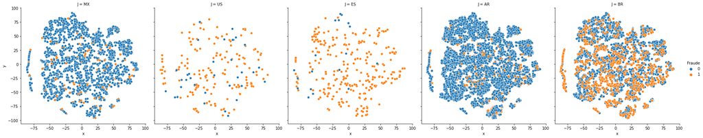

```python
sns.relplot(data=tsne_df, x="x", y="y",
            kind="scatter", col="J", hue="Fraude")
```

Como se puede observar parece haber un comportamiento similar entre US, y ES. Mientras que el comportamiento para los demás países parece ser muy particular para cada uno. Adicional que anteriormente se podía ver que el desbalance de clase para cada país es diferente.

Dado estos últimos hallazgos se decide construir cuatro modelos:

- Un modelo para US y ES.
- Un modelo para AR
- Un modelo para BR
- Un modelo para MX

## Entrenamiento y evaluación

Si bien se menciona que se construyen cuatro modelos, también se probó construyendo un modelo general donde no se obtuvieron muy buenos resultados para US y ES porque el algoritmo tenía un sesgo a predecir la mayoría de observaciones como fraudulentas, cuando hemos visto que en el caso particular de estos países el desbalance es diferente.

La metodología es la siguiente:

1. Se selecciona el set de datos para cada caso particular y se parte en entrenamiento y prueba.
2. Se exporta como un **csv** la data de entrenamiento para comparar la distribución entre entrenamiento y los datos nuevos. Esto con el objetivo de detectar cambios en los datos que pueden conllevar a que el modelo se degrade y no funcione correctamente.
3. Se define un **Pipeline** de preprocesamiento según sea el caso con el objetivo de garantizar las mismas transformaciones en los datos nuevos que se aplicaron en el entrenamiento.
4. Se instancian los algoritmos.
5. Se ajustan los algoritmos usando la validación cruzada para tener una estimación del error de generalización que podrían tener los algoritmos.
6. Se optimizan los hiperparametros del algoritmo seleccionado y se evalúa su rendimiento en los datos de prueba (datos no observados).

Adicional para cada modelo se muestra la interpretabilidad global del modelo.

### Primer modelo (US - ES)

Para este primer modelo, se selecciona solo las observaciones para estos países.

```python
data_modeling = data[data["J"].isin(["ES", "US"])]

train_data, test_data, train_label, test_label = split_train_test_data(data=data_modeling, label="Fraude", stratify=True)
```

```python
export_data(data=train_data, filepath="data/train/train_es_us.csv")
```

#### Validación cruzada

A continuación, se crea el Pipeline de preprocesamiento.

El Pipeline tiene los siguientes pasos:

- Preprocesamiento numérico
  - Selecciona las variables numéricas.
  - Imputa los datos missing usando un algoritmo KNN.
  - Escala los datos.
  - Devuelve los datos en un DataFrame
- Preprocesamiento categórico
  - Selecciona las variables categóricas.
  - Las codifica transformándolas en dummies

Al final se unen ambos resultados del preprocesamiento para pasarle los datos listos a un algoritmo.

```python
preprocessing = create_preprocess_pipeline(numerical_features=numerical_features,
                                           categorical_features=categorical_features, ohe_features=["J_ES", "J_US"])
```

Se van a utilizar cuatro algoritmos: Regresión Logística, K-NN, Random Forest y XGBoost. Dado que existe un desbalance de clases, para la Regresión Logística y el Random Forest se usa el parámetro de clase *class_weight* con el valor *balanced* para que en la optimización le de una ponderación mal alta a la clase menos representada para que el algoritmo se lo más justo posible para ambas clases. Por otro lado, para el XGBoost se calcula el número de observaciones de la clase negativa por observaciones de la clase positiva con el fin de ponderar las clases.

```python
counter = Counter(train_label)

scale_pos_weight = np.round(counter[0]/counter[1], 2)

lr = Pipeline(steps=[('preprocessing', preprocessing),
                     ('logistic_regression', LogisticRegression(class_weight="balanced",
                                                                max_iter=5000, random_state=42))])

knn = Pipeline(steps=[('preprocessing', preprocessing),
                      ('knn', KNeighborsClassifier(n_jobs=-1))])

rf = Pipeline(steps=[('preprocessing', preprocessing),
                     ('random_forest', RandomForestClassifier(class_weight="balanced",
                                                                   random_state=42))])

xgb = Pipeline(steps=[('preprocessing', preprocessing),
                      ('xgboost', XGBClassifier(max_depth=3, subsample=0.8, scale_pos_weight=scale_pos_weight,
                                                colsample_bytree=1, gamma=1, learning_rate=0.01,
                                                random_state=42))])
```

Se utiliza una validación cruzada haciendo un muestreo estratificado dado que tenemos un desbalance de clases. Se calculan las métricas: AUC, Precision, Recall y F1 para cada uno de los algoritmos.

**Nota**: No se calcula el Accuracy debido a que es una métrica que no es confiable cuando las clases están desbalanceadas.

```python
cv = RepeatedStratifiedKFold(n_splits=5, n_repeats=3, random_state=42)

estimators = [("logistic_regression", lr),
              ("knn", knn),
              ("random_forest", rf),
              ("xgboost", xgb)]

roc = cross_validation(data=train_data, label=train_label, estimators=estimators, scoring="roc_auc")
precision = cross_validation(data=train_data, label=train_label, estimators=estimators, scoring="precision")
recall = cross_validation(data=train_data, label=train_label, estimators=estimators, scoring="recall")
f1_score = cross_validation(data=train_data, label=train_label, estimators=estimators, scoring="f1")
```

```python
metrics = ["AUC", "Precision", "Recall", "F1"]

cross_validation_result(metrics_df=[roc, precision, recall, f1_score], names=metrics)
```

|  | AUC | Precision | Recall | F1 |
| --- | --- | --- | --- | --- |
| logistic_regression | 0.79 | 0.95 | 0.79 | 0.86 |
| knn | 0.66 | 0.91 | 0.98 | 0.95 |
| random_forest | 0.81 | 0.92 | 0.99 | 0.95 |
| xgboost | 0.80 | 0.95 | 0.80 | 0.87 |

Se puede observar que la Regresión Logística, el XGBoost y el Random Forest tienen los mejores resultados. Sin embargo, dado que hay muy pocas observaciones para ES y US, se ajusta la Regresión Logística dado que es un algoritmo más sencillo y no corre tanto riesgo de sobreajustarse como los otros.

#### Optimización de Hiperparametros

##### Regresión Logística

Se define el espacio de valores de los pocos hiperparametros que tiene la Regresión Logística.

```python
logit_params = {
    "logistic_regression__C": np.logspace(start=-3, stop=3, num=10),
    "logistic_regression__penalty": ["l1", "l2"]
}

lr_cv = GridSearchCV(estimator=lr, param_grid=logit_params, scoring="roc_auc", cv=5, n_jobs=-1)

lr_cv.fit(train_data, train_label)
```

A continuación, podemos ver como se comporta la Regresión Logística en los datos de prueba.

- El AUC del modelo es 0.78 que es un AUC bueno.
- FP (Error tipo I) de 25%.
- FN (Error tipo II) de 19%.

```python
class_names = {0: "No", 1: "Si"}

model = lr_cv.best_estimator_

evaluation = ClassificationEvaluator(observed=test_label, predicted=model.predict(test_data))
evaluation.print_metrics()
evaluation.confusion_matrix(class_names=class_names, normalize="index")
```

```
El AUC es: 0.78
La Exactitud es: 0.8
La Precision es: 0.97
La Exhaustividad es: 0.81
El F1 es: 0.88
```

| Predicted Observed | No | Si |
| --- | --- | --- |
| No | 0.75 | 0.25 |
| Si | 0.19 | 0.81 |

Además vemos que el modelo tiene mejor rendimiento en ES, donde el AUC es 0.78, es decir, se considera como un test bueno, por otro lado, para US se obtiene un AUC de 0.72 que se considera un test regular casi llegando a ser bueno.

```python
test = characterization_data(observed=test_label, predicted=model.predict(test_data), data=test_data)

for country in test["J"].unique():
    idx = test[test["J"] == country].index.tolist()
    print(f"Para {country} tenemos: \n")
    evaluation = ClassificationEvaluator(observed=test.loc[idx, "Fraude"], predicted=test.loc[idx, "prediction"])
    evaluation.print_metrics()
    display(evaluation.confusion_matrix(class_names=class_names))
```

```
Para US tenemos:

El AUC es: 0.72
La Exactitud es: 0.67
La Precision es: 0.94
La Exhaustividad es: 0.65
El F1 es: 0.77
```

| Predicted Observed | No | Si |
| --- | --- | --- |
| No | 8 | 2 |
| Si | 17 | 31 |

```
Para ES tenemos:

El AUC es: 0.78
La Exactitud es: 0.88
La Precision es: 0.98
La Exhaustividad es: 0.89
El F1 es: 0.93
```

| Predicted Observed | No | Si |
| --- | --- | --- |
| No | 4 | 2 |
| Si | 10 | 81 |

Se calcula el monto total y la cantidad de transacciones que se pueden categorizar como **VP**, **VN**, **FP**, y **FN**.

```python
test.groupby(by="categorization").agg(sum_monto=('Monto', "sum"),
                                      cant_trx=('categorization', 'count'))
```

| categorization | sum_monto | cant_trx |
| --- | --- | --- |
| FN | 3362.75 | 27 |
| FP | 471.94 | 4 |
| VN | 5553.93 | 12 |
| VP | 13006.45 | 112 |

Finalmente se procede a calcular los betas de la Regresión Logística con el fin de obtener una interpretación de como afecta la probabilidad un cambio en alguna variable.

#### Interpretabilidad global del modelo

```python
estimator = model["logistic_regression"]
model_data = model["preprocessing"].transform(train_data)
new_data = model["preprocessing"].transform(test_data)
```

```python
betas = pd.DataFrame({"feature": new_data.columns,
                      "beta": np.round(np.exp(model["logistic_regression"].coef_[0]), 3)}).sort_values(by="beta", ascending=False)
betas["interpretation"] = betas.apply(lambda x: beta_interpretation(x.feature, x.beta), axis=1)
betas
```

|  | feature | beta | interpretation |
| --- | --- | --- | --- |
| 1 | B | 3.04 | Por cada aumento de una unidad en B, la probab... |
| 18 | J_ES | 1.83 | Por cada aumento de una unidad en J_ES, la pro... |
| 16 | S | 1.79 | Por cada aumento de una unidad en S, la probab... |
| 0 | A | 1.65 | Por cada aumento de una unidad en A, la probab... |
| 13 | P | 1.47 | Por cada aumento de una unidad en P, la probab... |
| 11 | N | 1.24 | Por cada aumento de una unidad en N, la probab... |
| 3 | D | 1.21 | Por cada aumento de una unidad en D, la probab... |
| 10 | M | 1.20 | Por cada aumento de una unidad en M, la probab... |
| 2 | C | 1.09 | Por cada aumento de una unidad en C, la probab... |
| 15 | R | 1.09 | Por cada aumento de una unidad en R, la probab... |
| 7 | H | 1.07 | Por cada aumento de una unidad en H, la probab... |
| 5 | F | 1.04 | Por cada aumento de una unidad en F, la probab... |
| 12 | O | 1.01 | Por cada aumento de una unidad en O, la probab... |
| 14 | Q | 1.00 | Por cada aumento de una unidad en Q, la probab... |
| 4 | E | 0.99 | Por cada aumento de una unidad en E, la probab... |
| 17 | Monto | 0.99 | Por cada aumento de una unidad en Monto, la pr... |
| 9 | L | 0.90 | Por cada aumento de una unidad en L, la probab... |
| 6 | G | 0.89 | Por cada aumento de una unidad en G, la probab... |
| 8 | I | 0.75 | Por cada aumento de una unidad en I, la probab... |
| 19 | J_US | 0.54 | Por cada aumento de una unidad en J_US, la pro... |

A continuación se imprime la interpretación de uno de los coeficientes:

```python
betas["interpretation"][0]
```

```
'Por cada aumento de una unidad en A, la probabilidad de que la transaccion sea fraudulenta es 1.645 veces mayor de que la transaccion no sea fraudulenta manteniendo todas las demás variables constantes.'
```

Se procede a guardar el modelo para usarlo más adelante.

```python
save_model(estimator=model, filepath="models/logistic_regression.joblib")
```

```
['models/logistic_regression.joblib']
```

### Segundo modelo (AR)

Se selecciona los datos para este modelo.

```python
data_modeling = data[data["J"].isin(["AR"])]

train_data, test_data, train_label, test_label = split_train_test_data(data=data_modeling, label="Fraude", stratify=True)
```

```python
export_data(data=train_data, filepath="data/train/train_ar.csv")
```

#### Validación cruzada

Se crea el Pipeline de preprocesamiento, sin embargo, este es diferente al anterior debido a que solo se usan variables numéricas. En el anterior dado que teníamos dos países como variable categórica se debía hacer una codificación de la variable J.

El Pipeline tiene los siguientes pasos:

- Selecciona las variables numéricas.
- Imputa los datos missing usando un algoritmo KNN.
- Escala los datos.
- Devuelve un DataFrame

```python
preprocessing = create_preprocess_pipeline(numerical_features=numerical_features,
                                           categorical_features=categorical_features, features="numeric")
```

```python
counter = Counter(train_label)

scale_pos_weight = np.round(counter[0]/counter[1], 2)

lr = Pipeline(steps=[('preprocessing', preprocessing),
                     ('logistic_regression', LogisticRegression(class_weight="balanced",
                                                                max_iter=5000, random_state=42))])

knn = Pipeline(steps=[('preprocessing', preprocessing),
                      ('knn', KNeighborsClassifier(n_jobs=-1))])

rf = Pipeline(steps=[('preprocessing', preprocessing),
                     ('random_forest', RandomForestClassifier(class_weight="balanced",
                                                                   random_state=42))])

xgb = Pipeline(steps=[('preprocessing', preprocessing),
                      ('xgboost', XGBClassifier(max_depth=3, subsample=0.8, scale_pos_weight=scale_pos_weight,
                                                colsample_bytree=1, gamma=1, learning_rate=0.01, random_state=42))])
```

```python
estimators = [("logistic_regression", lr),
              ("knn", knn),
              ("random_forest", rf),
              ("xgboost", xgb)]

roc = cross_validation(data=train_data, label=train_label, estimators=estimators, scoring="roc_auc")
precision = cross_validation(data=train_data, label=train_label, estimators=estimators, scoring="precision")
recall = cross_validation(data=train_data, label=train_label, estimators=estimators, scoring="recall")
f1_score = cross_validation(data=train_data, label=train_label, estimators=estimators, scoring="f1")
```

```python
metrics = ["AUC", "Precision", "Recall", "F1"]

cross_validation_result(metrics_df=[roc, precision, recall, f1_score], names=metrics)
```

|  | AUC | Precision | Recall | F1 |
| --- | --- | --- | --- | --- |
| logistic_regression | 0.74 | 0.45 | 0.63 | 0.53 |
| knn | 0.69 | 0.51 | 0.35 | 0.42 |
| random_forest | 0.76 | 0.61 | 0.31 | 0.41 |
| xgboost | 0.74 | 0.43 | 0.75 | 0.54 |

Similar al caso anterior los mejores algoritmos son la Regresión Logística, el Random Forest y el XGBoost. Se elige ajustar el XGBoost dado que tiene mejores métricas de Recall y F1.

#### Optimización de hiperparametros

##### XGBoost

Se crea el espacio de valores de los hiperparametros y se procede a ajustar usando la clase *GridSearchCV*.

```python
params = {
    "xgboost__n_estimators": [100, 250, 500],
    "xgboost__max_depth": [3, 5, 7],
    "xgboost__subsample": [0.8, 0.9],
    "xgboost__reg_lambda": [1, 10]
}

xgb_cv = GridSearchCV(estimator=xgb, param_grid=params, scoring="roc_auc", cv=5, n_jobs=-1)

xgb_cv.fit(train_data, train_label)
```

A continuación, podemos ver como se comporta el XGBoost en los datos de prueba.

- El AUC del modelo es 0.7 que se considera un test bueno.

```python
model = xgb_cv.best_estimator_

evaluation = ClassificationEvaluator(observed=test_label, predicted=model.predict(test_data))
evaluation.print_metrics()
evaluation.confusion_matrix(class_names=class_names)
```

```
El AUC es: 0.7
La Exactitud es: 0.71
La Precision es: 0.49
La Exhaustividad es: 0.67
El F1 es: 0.56
```

| Predicted Observed | No | Si |
| --- | --- | --- |
| No | 1437 | 544 |
| Si | 257 | 516 |

Se calcula el monto total y la cantidad de transacciones que se pueden categorizar como **VP**, **VN**, **FP**, y **FN**.

```python
test = characterization_data(observed=test_label,
                             predicted=model.predict(test_data), data=test_data)
test.groupby(by="categorization").agg(cant_trx=("categorization", "count"),
                                      sum_monto=("Monto", "sum"))
```

| categorization | cant_trx | sum_monto |
| --- | --- | --- |
| FN | 257 | 47708.34 |
| FP | 544 | 64110.20 |
| VN | 1437 | 291001.20 |
| VP | 516 | 52434.12 |

##### Interpretabilidad global

Aprovechando el módulo SHAP se calcula el gráfico de importancia de las variables. Este gráfico nos muestra cuáles son las variables más importantes con el que se han formado los distintos árboles del ensamble. Aunque el XGBoost es un algoritmo no parámetrico y por tanto no es fácil de interpretar, este gráfico nos ayuda a entender un poco que variables se tienen en cuenta con mayor ponderación para generar la probabilidad de si una transacción es fraudulenta o no.

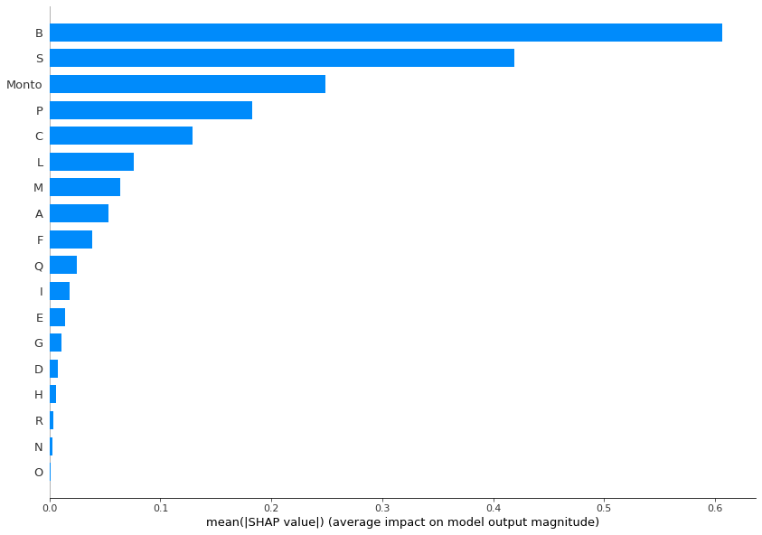

```python
estimator = model["xgboost"]
new_data = model["preprocessing"].transform(test_data)

explainer, shap_values = calculate_shap_values(estimator=estimator, new_data=new_data)

plot_feature_importance(shap_values=shap_values, data=new_data)
```

Las variables más importantes son:

- B
- S
- Monto

Se guarda el modelo para usarlo posteriormente

```python
save_model(estimator=model, filepath="models/xgboost_ar.joblib")
```

```
['models/xgboost_ar.joblib']
```

### Tercer modelo (MX)

Seleccionamos los datos para la construcción del modelo para MX

```python
data_modeling = data[data["J"].isin(["MX"])]

train_data, test_data, train_label, test_label = split_train_test_data(data=data_modeling, label="Fraude", stratify=True)
```

```python
export_data(data=train_data, filepath="data/train/train_mx.csv")
```

#### Validación cruzada

En este caso también el Pipeline de preprocesamiento solo es con variables numéricas. El Pipeline tiene los siguientes pasos:

- Selecciona las variables numéricas.
- Imputa los datos missing usando un algoritmo KNN.
- Escala los datos.
- Devuelve un DataFrame

```python
counter = Counter(train_label)

scale_pos_weight = np.round(counter[0]/counter[1], 2)

xgb = Pipeline(steps=[('preprocessing', preprocessing),
                      ('xgboost', XGBClassifier(max_depth=3, subsample=0.8, scale_pos_weight=scale_pos_weight,
                                                colsample_bytree=1, gamma=1, learning_rate=0.01,
                                                random_state=42))])
```

```python
estimators = [("logistic_regression", lr),
              ("knn", knn),
              ("random_forest", rf),
              ("xgboost", xgb)]

roc = cross_validation(data=train_data, label=train_label, estimators=estimators, scoring="roc_auc")
precision = cross_validation(data=train_data, label=train_label, estimators=estimators, scoring="precision")
recall = cross_validation(data=train_data, label=train_label, estimators=estimators, scoring="recall")
f1_score = cross_validation(data=train_data, label=train_label, estimators=estimators, scoring="f1")
```

```python
metrics = ["AUC", "Precision", "Recall", "F1"]

cross_validation_result(metrics_df=[roc, precision, recall, f1_score], names=metrics)
```

|  | AUC | Precision | Recall | F1 |
| --- | --- | --- | --- | --- |
| logistic_regression | 0.71 | 0.17 | 0.60 | 0.27 |
| knn | 0.62 | 0.20 | 0.03 | 0.05 |
| random_forest | 0.69 | 0.40 | 0.03 | 0.06 |
| xgboost | 0.70 | 0.18 | 0.62 | 0.28 |

Se elige el XGBoost debido a su mejor rendimiento en las métricas de Recall y F1.

#### Optimización de hiperparametros

##### XGBoost

```python
xgb_cv = GridSearchCV(estimator=xgb, param_grid=params, scoring="roc_auc", cv=5, n_jobs=-1)

xgb_cv.fit(train_data, train_label)
```

- El AUC del modelo es 0.67 que se considera un test regular.

```python
model = xgb_cv.best_estimator_

evaluation = ClassificationEvaluator(observed=test_label, predicted=model.predict(test_data))
evaluation.print_metrics()
evaluation.confusion_matrix(class_names=class_names)
```

```
El AUC es: 0.67
La Exactitud es: 0.73
La Precision es: 0.19
La Exhaustividad es: 0.59
El F1 es: 0.28
```

| Predicted Observed | No | Si |
| --- | --- | --- |
| No | 474 | 167 |
| Si | 26 | 38 |

Se calcula el monto total y la cantidad de transacciones que se pueden categorizar como **VP**, **VN**, **FP**, y **FN**.

```python
test = characterization_data(observed=test_label,
                             predicted=model.predict(test_data), data=test_data)
test.groupby(by="categorization").agg(cant_trx=("categorization", "count"),
                                      sum_monto=("Monto", "sum"))
```

| categorization | cant_trx | sum_monto |
| --- | --- | --- |
| FN | 26 | 4118.20 |
| FP | 167 | 27734.88 |
| VN | 474 | 89636.16 |
| VP | 38 | 6251.27 |

#### Interpretabilidad global

Similar al caso anterior, se muestra el gráfico de importancia de las variables.

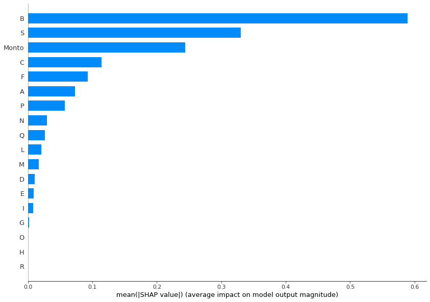

```python
estimator = model["xgboost"]
new_data = model["preprocessing"].transform(test_data)

explainer, shap_values = calculate_shap_values(estimator=estimator, new_data=new_data)

plot_feature_importance(shap_values=shap_values, data=new_data)
```

Las variables más importantes son:

- B
- S
- Monto

Se procede a guardar el modelo para usarlo más adelante.

```python
save_model(estimator=model, filepath="models/xgboost_mx.joblib")
```

```
['models/xgboost_mx.joblib']
```

### Cuarto modelo (BR)

Se selecciona los datos para entrenar el modelo para BR.

```python
data_modeling = data[data["J"].isin(["BR"])]

train_data, test_data, train_label, test_label = split_train_test_data(data=data_modeling, label="Fraude", stratify=True)
```

```python
export_data(data=train_data, filepath="data/train/train_br.csv")
```

#### Validación cruzada

Se usa el mismo Pipeline definido anteriormente. El Pipeline tiene los siguientes pasos:

- Selecciona las variables numéricas.
- Imputa los datos missing usando un algoritmo KNN.
- Escala los datos.
- Devuelve un DataFrame

```python
counter = Counter(train_label)

scale_pos_weight = np.round(counter[0]/counter[1], 2)

xgb = Pipeline(steps=[('preprocessing', preprocessing),
                      ('xgboost', XGBClassifier(max_depth=3, subsample=0.8, scale_pos_weight=scale_pos_weight,
                                                colsample_bytree=1, gamma=1, learning_rate=0.01,
                                                random_state=42))])
```

```python
estimators = [("logistic_regression", lr),
              ("knn", knn),
              ("random_forest", rf),
              ("xgboost", xgb)]

roc = cross_validation(data=train_data, label=train_label, estimators=estimators, scoring="roc_auc")
precision = cross_validation(data=train_data, label=train_label, estimators=estimators, scoring="precision")
recall = cross_validation(data=train_data, label=train_label, estimators=estimators, scoring="recall")
f1_score = cross_validation(data=train_data, label=train_label, estimators=estimators, scoring="f1")
```

```python
metrics = ["AUC", "Precision", "Recall", "F1"]

cross_validation_result(metrics_df=[roc, precision, recall, f1_score], names=metrics)
```

|  | AUC | Precision | Recall | F1 |
| --- | --- | --- | --- | --- |
| logistic_regression | 0.76 | 0.45 | 0.65 | 0.53 |
| knn | 0.69 | 0.53 | 0.29 | 0.37 |
| random_forest | 0.77 | 0.66 | 0.30 | 0.41 |
| xgboost | 0.76 | 0.43 | 0.70 | 0.53 |

#### Optimización de hiperparametros

##### Regresión Logística

```python
lr_cv = GridSearchCV(estimator=lr, param_grid=logit_params, scoring="roc_auc", cv=5, n_jobs=-1)

lr_cv.fit(train_data, train_label)
```

- El AUC es 0.72 que se considera como un test bueno.

```python
model = lr_cv.best_estimator_

evaluation = ClassificationEvaluator(observed=test_label, predicted=model.predict(test_data))
evaluation.print_metrics()
evaluation.confusion_matrix(class_names=class_names)
```

```
El AUC es: 0.72
La Exactitud es: 0.73
La Precision es: 0.46
La Exhaustividad es: 0.7
El F1 es: 0.56
```

| Predicted Observed | No | Si |
| --- | --- | --- |
| No | 724 | 263 |
| Si | 98 | 228 |

Se calcula el monto total y la cantidad de transacciones que se pueden categorizar como **VP**, **VN**, **FP**, y **FN**.

```python
test = characterization_data(observed=test_label,
                             predicted=model.predict(test_data), data=test_data)
test.groupby(by="categorization").agg(cant_trx=("categorization", "count"),
                                      sum_monto=("Monto", "sum"))
```

| categorization | cant_trx | sum_monto |
| --- | --- | --- |
| FN | 98 | 21113.00 |
| FP | 263 | 34596.70 |
| VN | 724 | 135737.87 |
| VP | 228 | 34211.92 |

#### Interpretabilidad global

Se procede a calcular los betas de la Regresión Logística.

```python
estimator = model["logistic_regression"]
model_data = model["preprocessing"].transform(train_data)
new_data = model["preprocessing"].transform(test_data)

betas = pd.DataFrame({"feature": new_data.columns,
                      "beta": np.round(np.exp(model["logistic_regression"].coef_[0]), 3)}).sort_values(by="beta", ascending=False)
betas["interpretation"] = betas.apply(lambda x: beta_interpretation(x.feature, x.beta), axis=1)
betas
```

|  | feature | beta | interpretation |
| --- | --- | --- | --- |
| 1 | B | 2.77 | Por cada aumento de una unidad en B, la probab... |
| 5 | F | 2.07 | Por cada aumento de una unidad en F, la probab... |
| 12 | O | 2.03 | Por cada aumento de una unidad en O, la probab... |
| 9 | L | 1.81 | Por cada aumento de una unidad en L, la probab... |
| 16 | S | 1.70 | Por cada aumento de una unidad en S, la probab... |
| 13 | P | 1.22 | Por cada aumento de una unidad en P, la probab... |
| 7 | H | 1.20 | Por cada aumento de una unidad en H, la probab... |
| 0 | A | 1.10 | Por cada aumento de una unidad en A, la probab... |
| 4 | E | 1.07 | Por cada aumento de una unidad en E, la probab... |
| 10 | M | 1.06 | Por cada aumento de una unidad en M, la probab... |
| 2 | C | 1.04 | Por cada aumento de una unidad en C, la probab... |
| 14 | Q | 1.00 | Por cada aumento de una unidad en Q, la probab... |
| 15 | R | 1.00 | Por cada aumento de una unidad en R, la probab... |
| 6 | G | 0.96 | Por cada aumento de una unidad en G, la probab... |
| 3 | D | 0.94 | Por cada aumento de una unidad en D, la probab... |
| 17 | Monto | 0.92 | Por cada aumento de una unidad en Monto, la pr... |
| 11 | N | 0.92 | Por cada aumento de una unidad en N, la probab... |
| 8 | I | 0.74 | Por cada aumento de una unidad en I, la probab... |

```python
betas["interpretation"][0]
```

```
'Por cada aumento de una unidad en A, la probabilidad de que la transaccion sea fraudulenta es 1.104 veces mayor de que la transaccion no sea fraudulenta manteniendo todas las demás variables constantes.'
```

Las variables que tienen más peso son:

- B
- F
- O

Se procede a guardar el modelo para usarlo más adelante.

```python
save_model(estimator=model, filepath="models/logistic_regression_br.joblib")
```

```
['models/logistic_regression_br.joblib']
```

## Consideraciones

- Se hicieron algunas correcciones a los datos. Tal vez no había que hacerlo y mi computador no tomó los datos como se debía.
- Se eliminaron valores -1 dado que se consideraron como posible información faltante para esa observación.
- Se tomaron todas las variables como numéricas. Esto es importante por el tipo de preprocesamiento que debe tener cada variable y que puede afectar también los resultados.
- Se encontraron muchos datos atípicos. Para esto se usaron algoritmos que no son tan sensibles a datos atípicos como es el caso del Random Forest y el XGBoost, sin embargo, los otros dos algoritmos si son sensibles a estos.

## Conclusiones

**Trabajo de mejora futuro**:

- Se calcularon la cantidad de transacciones y montos en los datos no observados con cada uno de los modelos, sin embargo, no se monetizaron los resultados.
- Modelar los datos atípicos para ayudarle a los algoritmos a aprender sobre estos patrones, esto se podría abordar de la siguiente manera:
  - Crear dummies para cada variable numérica donde 1 representa que la observación es un dato atípico en esa variable, y 0 en caso contrario.
  - Entrenar un algoritmo de detección de anomalías que clasifique las observaciones entre anomalía y normal, y pasar este resultado como una variable independiente.
- Usar técnicas de reducción de la dimensionalidad que funcione para variables categóricas y numéricas para tal vez entder un poco más la estructura multivariada de los datos.
- Hacer un análisis exhaustivo sobre las observaciones que se clasificaron como **FN** y **FP** para entender porque no fueron correctamente clasificadas, y mirar si se puede corregir algo desde la ingeniería de características.
- Interpretabilidad local
  - Con los valores shap que se calcularon hacer interpretación local, es decir, explicar para cada observación que variable afectó más la probabilidad de clasificarse como una transacción fraudulenta o no.
  - Dado que no se encontró multicolinealidad, hacer gráficas de dependencia parcial (PDP).